# Project 1

We will work with the dataset `olympics_top` that contains data for the Olympic Games from Athens 1896 to Rio 2016 and has been derived from the `olympics` dataset. More information about the dataset can be found at: https://github.com/rfordatascience/tidytuesday/blob/master/data/2021/2021-07-27/readme.md The dataset, `olympics_top`, contains four new columns: `decade` (the decade during which the Olympics took place), `gold` (whether or not the athlete won a gold medal), `medalist` (whether or not the athlete won any medal) and `medal` (if the athlete won “Gold”, “Silver”, “Bronze” or received “no medal”).

### **Part 1**

**Question:** Which sports have the tallest or shortest athletes? And does the distribution of heights change for the various sports between medalists and non-medalists?

**Introduction:** *In this project I will be analyzing over 80,000 data points from various summer and winter olympic games. Our dataset includes information like the the name, sex, age, height and weight of the athletes. It also includes information on the country they represented and the events and sports that they took apart in. It also includes whether they were able to medal or not and if they did what medal they were able to take home. Using this data I will be able to create various graphs to be able to visualize the information.*

*To answer the first part of this project I will be using the continuous height variable and the discrete sport variable while for the second part I will be using the discrete medalist variable along with the continuous height variable faceted by sport.*

**Analysis:**

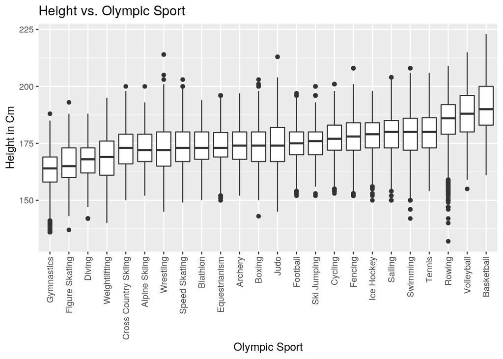

```r
#creation of Boxplot adjusting to reorder by median
plot1<-ggplot(olympics_top, aes(y = height, x = reorder(sport,height,na.rm=T))) +
  geom_boxplot(fill = "white")+
  ylab("Height in Cm")+
  xlab("Olympic Sport")+
  labs(title = "Height vs. Olympic Sport")+
  theme(axis.text.x = element_text(angle = 90, vjust = 0.5, hjust=1))
plot1
```

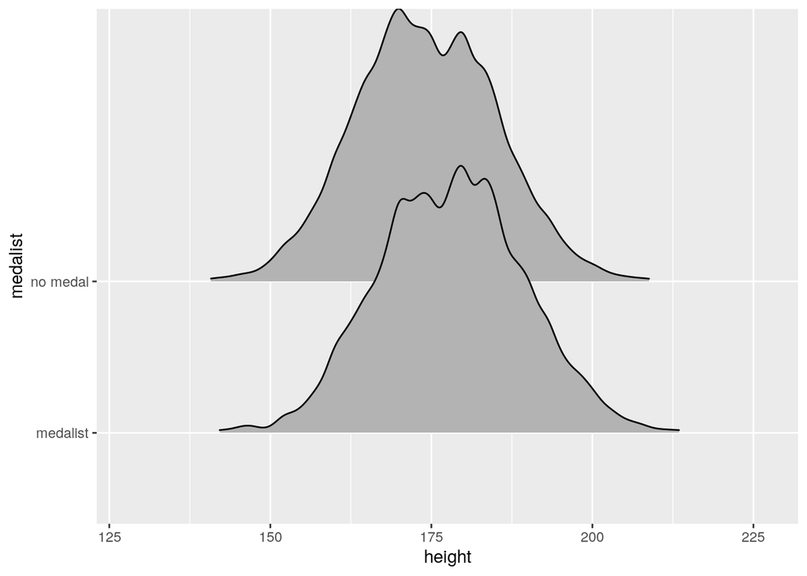

```r
library(ggridges) # for geom_density_ridges
plot2<-ggplot(olympics_top, aes(x = height, y= medalist))+
    geom_density_ridges(rel_min_height = 0.01,na.rm = T,show.legend = F,)

plot3<-ggplot(olympics_top, aes(x = height, y= medalist,fill=sport))+
    geom_density_ridges(rel_min_height = 0.01,na.rm = T,show.legend = F,)+
    facet_wrap(~sport,nrow = 6,ncol = 4)+
      xlab("Height in Cm")+
      ylab("Medalist or Non-medalist")+
      labs(title = "Medalist or non-medalist vs. height subsetting by sport")
  #I removed the legend because the names of the sport is already present.
  suppressMessages(print(plot2))
```

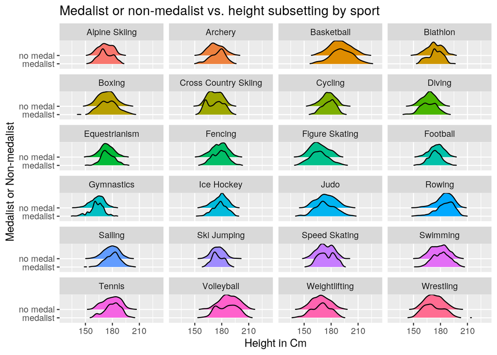

```r
  suppressMessages(print(plot3))
```

```r
  #used this data wrangling to furhter analyze
  olympics_top %>% count(sport,medalist,sex)
```

```
## # A tibble: 96 x 4
##    sport         medalist sex       n
##    <chr>         <chr>    <chr> <int>
##  1 Alpine Skiing medalist F       130
##  2 Alpine Skiing medalist M       109
##  3 Alpine Skiing no medal F      1743
##  4 Alpine Skiing no medal M      2060
##  5 Archery       medalist F        37
##  6 Archery       medalist M       121
##  7 Archery       no medal F       394
##  8 Archery       no medal M       472
##  9 Basketball    medalist F       227
## 10 Basketball    medalist M       391
## # … with 86 more rows
```

**Discussion:** *The first graph shows the heights of the athletes respective to what sport they played so that their heights could be compared to one another. The graph went pretty much how I expected it considering the size limitations of some sports. The best gymnasts are smaller because of their low center of gravity while the best basketball players are taller than the average olympian. My second graph takes a look at medalists and non-medalists vs height. I saw very little change between these two groups this led me to an in-depth analysis for my third graph. For my third graph I compared the heights between the medalists and non-medalists while faceting for sport I could not see differences between many of the sports with a few exceptions. However, these exceptions can be explained by a much larger number of men’s medalist but number of non-medalist staying identical for some sports this likely made the graph skewed towards a higher height. I can hypothesize that most olympians who compete in the games are already of an elite height and most of the difference between who medals and doesn’t is likely due to skill rather than the height of the athlete.*

### **Part 2**

**Question:** *Are athletes getting younger or older as we moved through the decades of the olympics games? If so, which sports is this trend most prevalent in?*

**Introduction:** *The olympics dataset includes all the information that we need to be able to answer this question. We will use the pre-made decades column and the age as well as the sports to create these two graphs to answer our questions.*

**Analysis:**

```r
#obtains table of average ages for each decade
olympics_top2 <- olympics_top %>% group_by(decade) %>% summarise(avg_age = mean(age,na.rm=T))
```

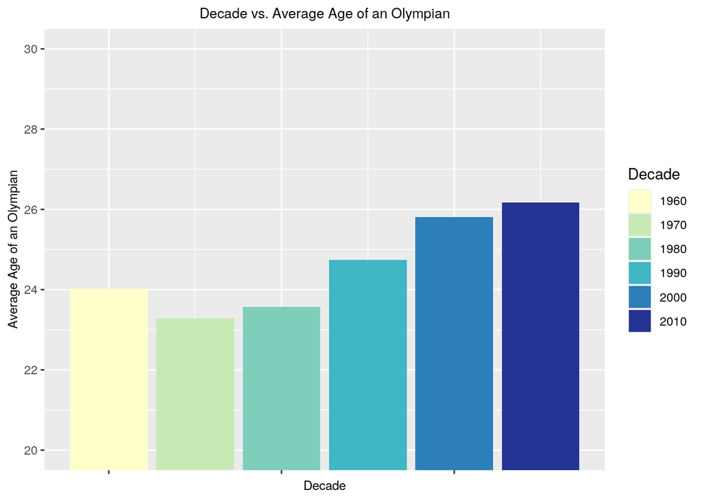

```r
#subset out years prior to 1960 because of copious amounts of missing data for the ages.
olympics_top2 <- olympics_top2[olympics_top2$decade > 1959,]

#creation of geom_col graph using coord_cartesian to zoom in to better grasp the differences between the decades
ggplot(data = olympics_top2, aes(x=decade,y=avg_age))+
  geom_col(aes(fill = as.factor(decade)))+
  xlab("Decade")+
  ylab("Average Age of an Olympian")+
  labs(fill = "Decade")+
  ggtitle("Decade vs. Average Age of an Olympian") +
  theme(axis.title.x = element_text(size = 9),
        axis.title.y = element_text(size = 9),
        axis.text.x = element_text(size = 0),
        plot.title = element_text(size = 10, hjust = 0.5)) +
  scale_fill_brewer(palette = 16)+
  scale_y_continuous(breaks = seq(0, 30, by = 2))+
  coord_cartesian(ylim = c(20,30))
```

```r
#gets grouping of decade and sport and average age.
olympics_top3 <- olympics_top %>% group_by(decade,sport) %>% summarise(avg_age = mean(age,na.rm=T))
```

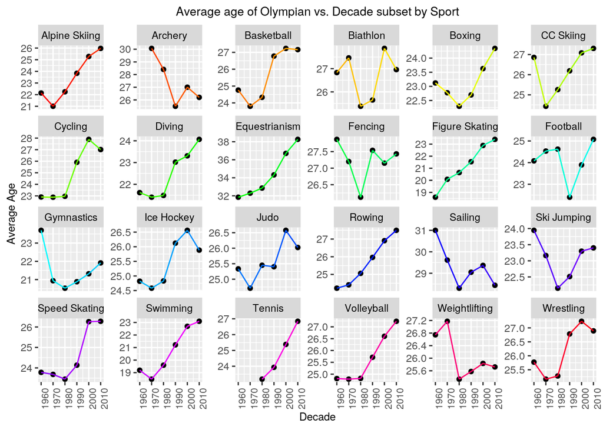

```r
#subset out years prior to 1960 because of copious amounts of missing data for the ages.
olympics_top3 <- olympics_top3[olympics_top3$decade > 1959,]
# Changes Cross Country Skiing to CC Skiing
olympics_top3[olympics_top3 == "Cross Country Skiing"]<- "CC Skiing"
#Created a geom_point graph to see the progression of age through different sports
#Used free_y in facet_wrap to better see individual sports.
ggplot(data = olympics_top3, aes(x=decade,y=avg_age,fill= sport))+
  geom_point(na.rm = T,show.legend = F)+
  geom_line(show.legend = F,color=rainbow(141))+
  facet_wrap(~sport,nrow = 4,ncol=6,scales = "free_y" )+
  ggtitle("Average age of Olympian vs. Decade subset by Sport")+
  xlab("Decade")+
  ylab("Average Age")+
  theme(axis.title.x = element_text(size = 9),
        axis.title.y = element_text(size = 9),
        axis.text.x = element_text(size = 8,angle = 90),
        plot.title = element_text(size = 10, hjust = 0.5),
        strip.text.x = element_text(size = 8.5, colour = "Black"))
```

**Discussion:** *The results of my analysis were quite surprising. Unlike what I had I thought athletes have not been getting younger. They have actually been getting older, while there is only about a two year difference between the 1960’s and 2010’s this is actually quite significant considering most athletes find it harder to compete as they get into their mid-thirties. While the overall trend was increasing this was not the trend of some sports. Sports like sailing, gymnastics, and archery had significant changes in their average ages in the opposite direction. Every sport is different and while overall trends are good to see for the entirety of the olympics it is much better to gain a deeper understanding of each sport to truly see the trends of the ages of the athletes.*